# 13주차 복습과제

김민주

2020 7 5

1-1. groceries의 거래내역중 가장 많이 거래되는 아이템중 5등을 찾아라

```r
library(arules)
```

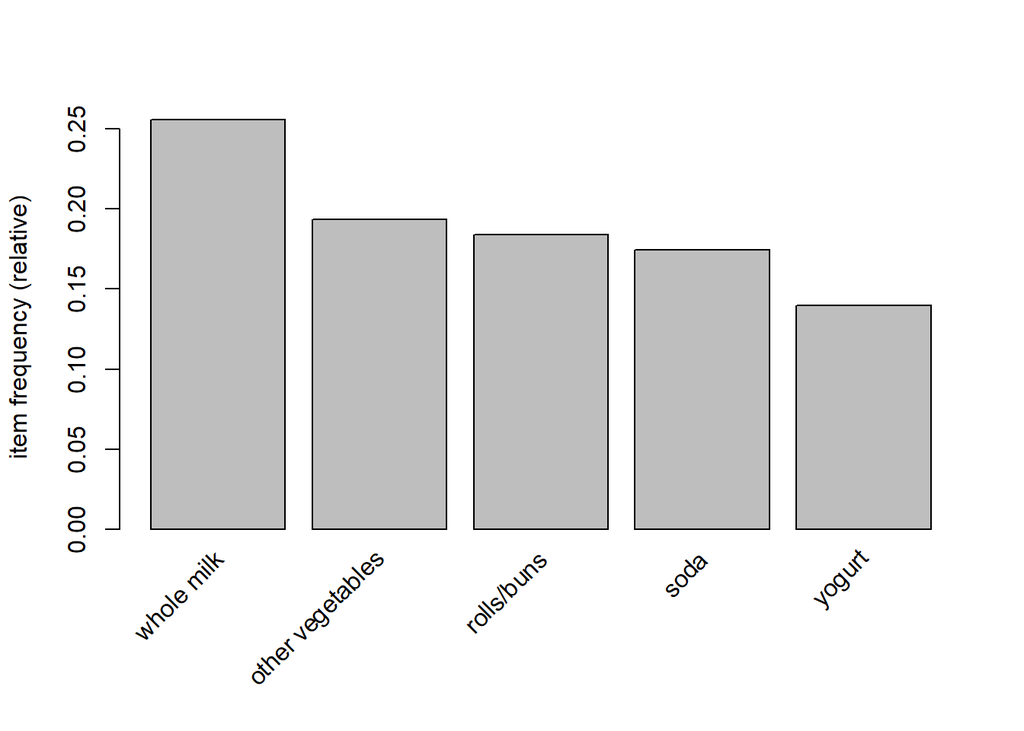

```r
groceries <- read.transactions("groceries.csv",sep=",")
# summary(groceries)
itemFrequencyPlot(groceries,topN=5)
```

groceries의 거래내역중 가장 많이 거래되는 아이템중 5등은 yogurt 이다.

1-2. groceries에 대한 장바구니 분석을 위해 규칙(rule)을 만들어라. support가 0.005이상, confidence가 0.6이상, 최소한 3개 이상의 아이템 집합에 대한 규칙을 만들면 총 몇개의 규칙이 생성되는가?

```r
rule <- apriori(groceries,parameter = list(support=0.005,confidence=0.6,minlen=3))
```

```
## Apriori
##
## Parameter specification:
##  confidence minval smax arem  aval originalSupport maxtime support minlen
##         0.6    0.1    1 none FALSE            TRUE       5   0.005      3
##  maxlen target  ext
##      10  rules TRUE
##
## Algorithmic control:
##  filter tree heap memopt load sort verbose
##     0.1 TRUE TRUE  FALSE TRUE    2    TRUE
##
## Absolute minimum support count: 49
##
## set item appearances ...[0 item(s)] done [0.00s].
## set transactions ...[169 item(s), 9835 transaction(s)] done [0.01s].
## sorting and recoding items ... [120 item(s)] done [0.00s].
## creating transaction tree ... done [0.00s].
## checking subsets of size 1 2 3 4 done [0.01s].
## writing ... [22 rule(s)] done [0.00s].
## creating S4 object  ... done [0.00s].
```

1-3. 해당규칙에 대하여, 시각화를 하고, 지지도 support가 가장 큰 규칙과 향상도 lift가 가장 큰 규칙을 말하라 (기준method는 grouped, type은 items)

[output not shown]

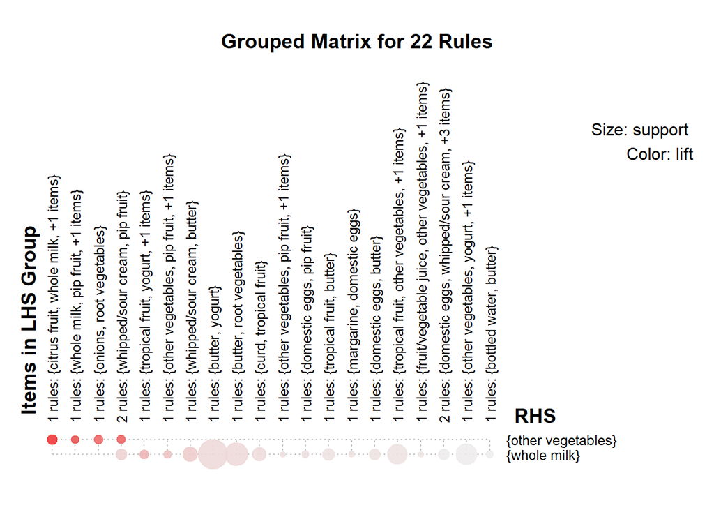

```r
library(arulesViz)
plot(rule, method="grouped",control=list(type="items"))
```

지지도 support가 가장 큰 규칙은 butter,yogurt 연관규칙이고, 향상도 lift가 가장 큰 규칙은 citrus fruit, wholemile, +1 items 연관규칙이다.

2-1.앞의 1에서 구한 규칙을 바탕으로, 신뢰도 confidence가 8번째로 큰 규칙을 찾으시오.

```r
inspect(sort(rule,by="confidence")[1:8])
```

```
##     lhs                     rhs                    support confidence    coverage     lift count
## [1] {root vegetables,
##      tropical fruit,
##      yogurt}             => {whole milk}       0.005693950  0.7000000 0.008134215 2.739554    56
## [2] {other vegetables,
##      pip fruit,
##      root vegetables}    => {whole milk}       0.005490595  0.6750000 0.008134215 2.641713    54
## [3] {butter,
##      whipped/sour cream} => {whole milk}       0.006710727  0.6600000 0.010167768 2.583008    66
## [4] {pip fruit,
##      whipped/sour cream} => {whole milk}       0.005998983  0.6483516 0.009252669 2.537421    59
## [5] {butter,
##      yogurt}             => {whole milk}       0.009354347  0.6388889 0.014641586 2.500387    92
## [6] {butter,
##      root vegetables}    => {whole milk}       0.008235892  0.6377953 0.012913066 2.496107    81
## [7] {curd,
##      tropical fruit}     => {whole milk}       0.006507372  0.6336634 0.010269446 2.479936    64
## [8] {citrus fruit,
##      root vegetables,
##      whole milk}         => {other vegetables} 0.005795628  0.6333333 0.009150991 3.273165    57
```

citrus fruit와 root vegetables, whole milk 를 사는 사람은 다른 채소도 구입한다.

2-2. 앞의 1에서 구한 규칙을 바탕으로, (1.1에서 구한 5번째로 가장많이 거래되는 아이템과 butter만을 함께 구매한 사람)에 대한 규칙을 만들자. (나머지는 구매하지 않고, 딱 이 2가지 물품만 구매한 사람) 이때 나온 규칙을 서술하고, lift값을 구하라

요거트와 butter만을 함께 구입한 사람에 대한 규칙?

```r
newrule <- subset(rule, items %ain% c('yogurt','butter'))
inspect(newrule)
```

```
##     lhs                rhs          support     confidence coverage   lift
## [1] {butter,yogurt} => {whole milk} 0.009354347 0.6388889  0.01464159 2.500387
##     count
## [1] 92
```

버터와 요거트를 같이 구매하는 사람은 전유를 구입한다. lift값은 2.500387이다.